# Prediction of NBA Shots

# Final Project

NBA data

Aidan and Liam Greenlee

# Data

- The data contains the information on shots during the 2014-2015 season.
  - Player who took the shot
  - Who was the closest defender
  - Shot clock
  - Shot distance
  - Distance to the closest defender
  - Shot number

# Preparing Data

```r
data1 <- na.omit(read.csv(file = "shot_logs.csv"))
data1$GAME_CLOCK<- as.double(ms(data1$GAME_CLOCK))
data1 <- data1 %>% mutate(SHOT_RESULT = ifelse(SHOT_RESULT == "made", 1, 0))
data <- data1[,c(1,3,4,5,6,7,8,9,10,11,12,13,14,16,17,21)]
data$GAME_CLOCK_TOT <- data$GAME_CLOCK+(data$PERIOD-1)*720
```

# Splitting Data

```r
set.seed(5040)
resample <- initial_split(prop = .7, data)
test <- testing(resample)
train <- training(resample)
split <- resample_partition(train, c(train1 = .1, train2 = .9))
train1 <- as_tibble(split$train1)
train2 <- as_tibble(split$train2)
train1
data
```

- full data set has 122,502 rows
- 70% training set still has 85,752 rows
- cut training set down to 8,575 rows

# Graph

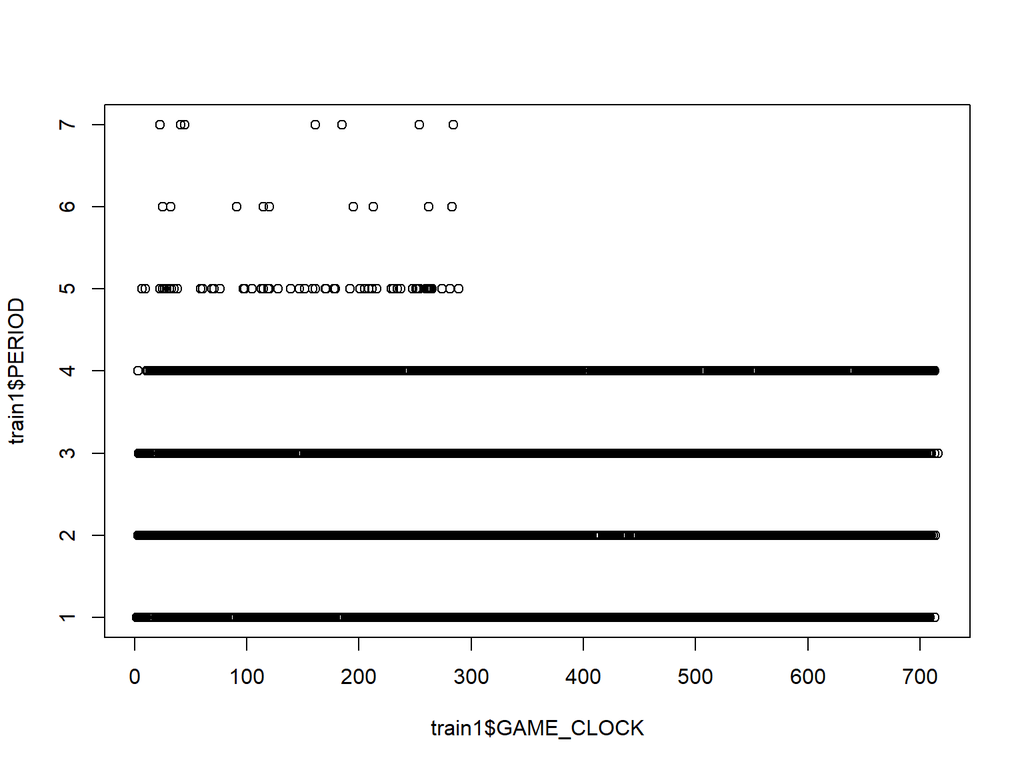

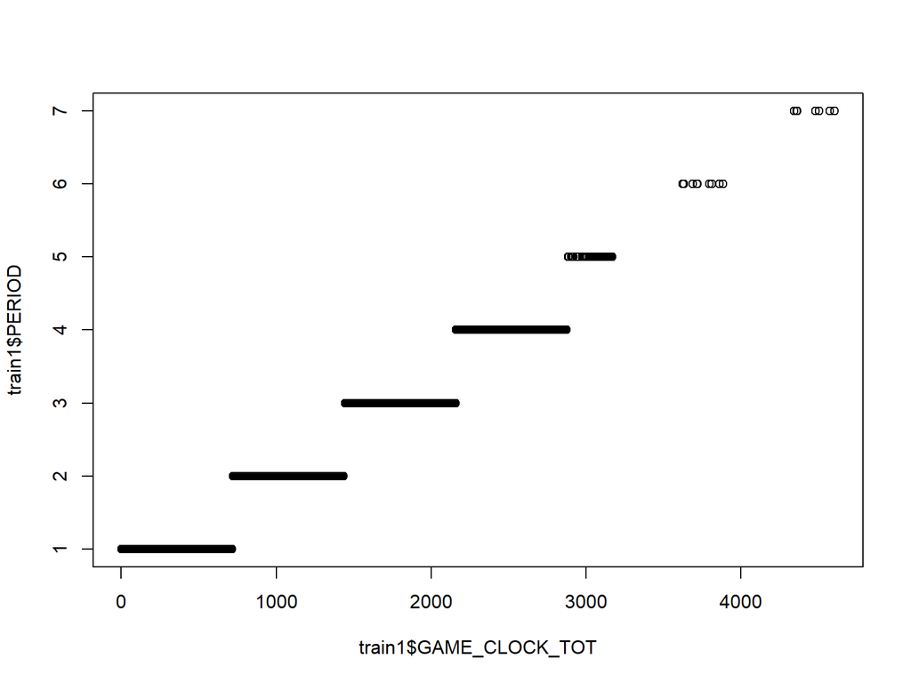

# Data Exploration

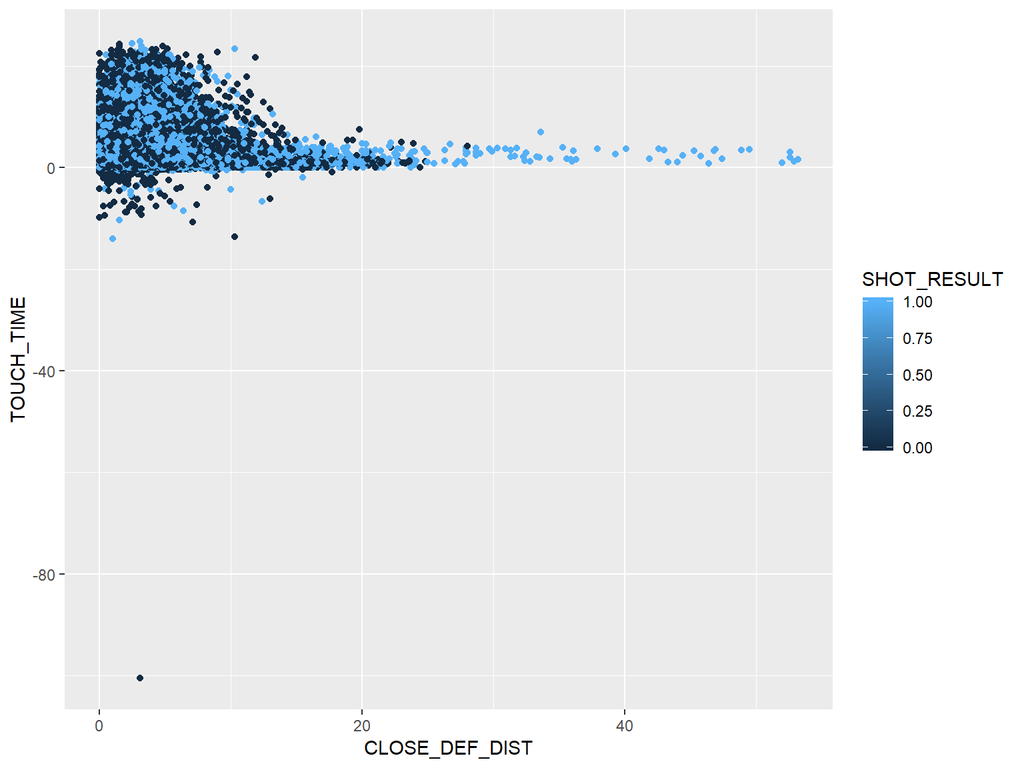

# Data Exploration

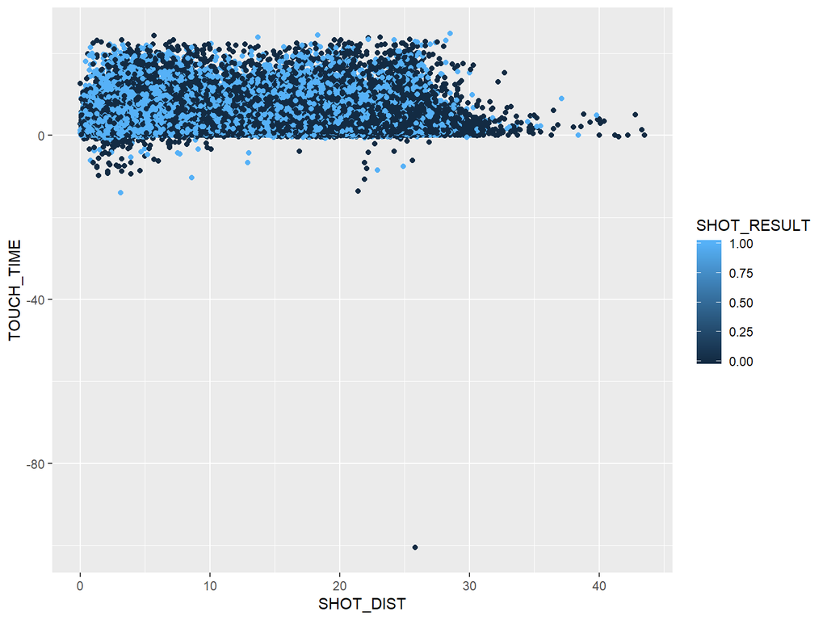

# Data Exploration

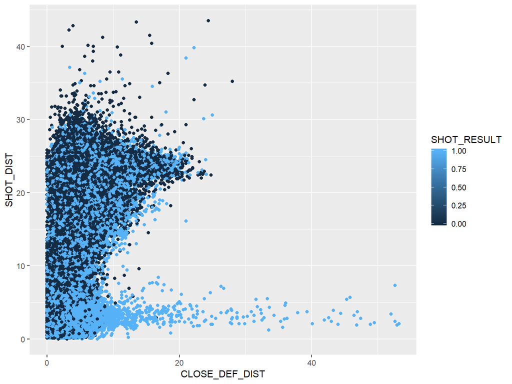

# Fit Data (Elastic Net)

```
## # A tibble: 11 x 4
##    alpha   lambda    cv  rank
##    <dbl>    <dbl> <dbl> <int>
##  1   0   0.0101    1.32    11
##  2   0.1 0.00261   1.32    10
##  3   0.2 0.00189   1.32     9
##  4   0.3 0.00152   1.32     8
##  5   0.4 0.00125   1.32     7
##  6   0.5 0.00100   1.32     3
##  7   0.6 0.000915  1.32     6
##  8   0.7 0.000784  1.32     4
##  9   0.8 0.000686  1.32     2
## 10   0.9 0.000610  1.32     1
## 11   1   0.000603  1.32     5
```

```
## # A tibble: 17 x 2
##    variable                         s0
##    <chr>                         <dbl>
##  1 CLOSE_DEF_DIST              1.02e-1
##  2 PTS_TYPE                    8.07e-2
##  3 SHOT_DIST                  -6.32e-2
##  4 TOUCH_TIME                 -4.81e-2
##  5 WW                          2.07e-2
##  6 DRIBBLES                    1.53e-2
##  7 SHOT_CLOCK                  1.48e-2
##  8 LOCATIONH                  -1.20e-2
##  9 FINAL_MARGIN                8.42e-3
## 10 SHOT_NUMBER                 5.73e-3
## 11 GAME_ID                    -8.42e-5
## 12 GAME_CLOCK_TOT             -2.32e-5
## 13 player_id                  -3.03e-7
## 14 CLOSEST_DEFENDER_PLAYER_ID -7.77e-9
## 15 (Intercept)                 0.
## 16 PERIOD                      0.
## 17 GAME_CLOCK                  0.
```

# Choosing Lambda With Elastic Net

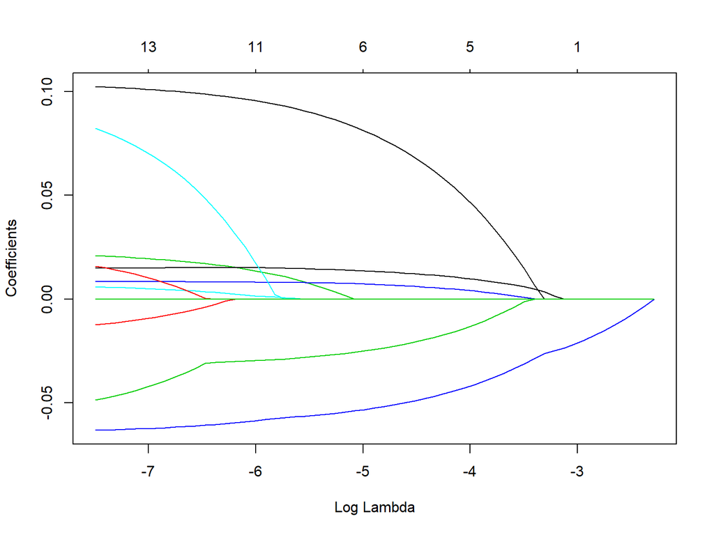

Elastic Net Misclassification Rate:

```
## [1] 0.4244626
```

# Logistic Regression

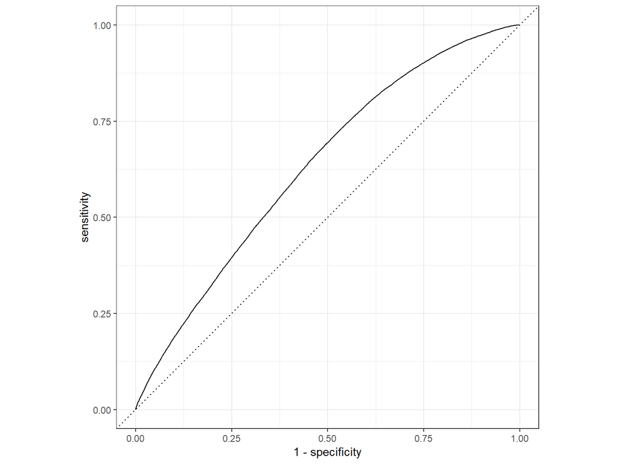

```
## # A tibble: 1 x 3
##   .metric .estimator .estimate
##   <chr>   <chr>          <dbl>
## 1 roc_auc binary         0.634
```

Misclassification Rate:

```
## [1] 0.3907755
```

# More fits, MSEs, and predictions

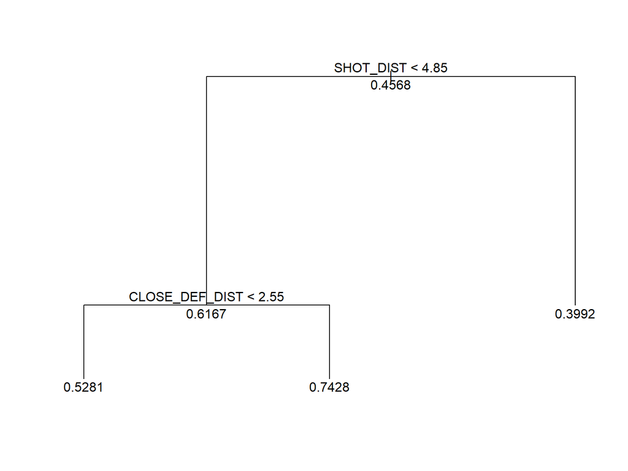

Tree and Linear Model MSEs:

```
## [1] 0.405551
```

```
## [1] 0.3917007
```

# Future Work

- Analyze hot hand hypothesis
  - A person who experiences a successful outcome has a greater chance of succes in further attempts
- Focus on one player
- Use position data
- Shot type
- Pull more data on the shot zone

# R Markdown

# Preparing Data

[output not shown]

[output cut: 18736 more lines]

# Splitting Data

```r
resample <- initial_split(prop = .7, data)
test <- testing(resample)
train <- training(resample)
split <- resample_partition(train, c(train1 = .1, train2 = .9))
train1 <- as_tibble(split$train1)
train2 <- as_tibble(split$train2)
train1
```

# Graph

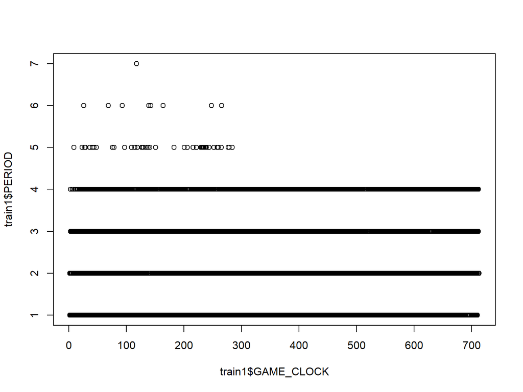

# Fit Data

```r
svmfit
```

```
##
## Call:
## svm(formula = SHOT_RESULT ~ LOCATION + W + FINAL_MARGIN + SHOT_NUMBER +
##     PERIOD + GAME_CLOCK + SHOT_CLOCK + DRIBBLES + TOUCH_TIME +
##     SHOT_DIST + PTS_TYPE + CLOSEST_DEFENDER_PLAYER_ID + CLOSE_DEF_DIST +
##     player_id + GAME_ID, data = train1, kernel = "radial", cost = 10,
##     gamma = 1)
##
##
## Parameters:
##    SVM-Type:  eps-regression
##  SVM-Kernel:  radial
##        cost:  10
##       gamma:  1
##     epsilon:  0.1
##
##
## Number of Support Vectors:  8537
```

```r
test$svmfit <- predict(svmfit, test)
test$lmfit <- predict(lmfit, test)
cvtree
```

```
## $size
## [1] 3 2 1
##
## $dev
## [1] 2016.040 2032.628 2126.107
##
## $k
## [1]      -Inf  25.10382 102.63220
##
## $method
## [1] "deviance"
##
## attr(,"class")
## [1] "prune"         "tree.sequence"
```

# MSEs and Predictions

```
##                               Overall
## LOCATIONH                   1.5776149
## WW                          1.0365154
## FINAL_MARGIN                2.6189573
## SHOT_NUMBER                 0.9810075
## PERIOD                      0.4725042
## GAME_CLOCK                  0.8323562
## SHOT_CLOCK                  2.2275022
## DRIBBLES                    1.3435115
## TOUCH_TIME                  2.8258084
## SHOT_DIST                  17.4713025
## PTS_TYPE                    2.3188755
## CLOSEST_DEFENDER_PLAYER_ID  0.4399025
## CLOSE_DEF_DIST             10.1954026
## player_id                   0.7516017
## GAME_ID                     1.1872793
```

```
## node), split, n, deviance, yval
##       * denotes terminal node
##
## 1) root 8575 2126.0 0.4540
##   2) SHOT_DIST < 6.05 2703  639.9 0.6152
##     4) CLOSE_DEF_DIST < 3.35 2080  511.9 0.5625 *
##     5) CLOSE_DEF_DIST > 3.35 623  102.9 0.7913 *
##   3) SHOT_DIST > 6.05 5872 1383.0 0.3798 *
```

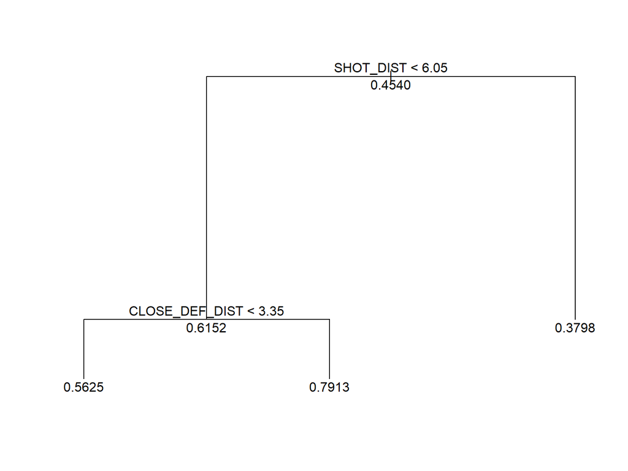

```
## after
```

```
## [1] 0.3985034
```

```
## [1] 0.3999728
```

```
## [1] 0.4457415
```